# Intro to R - Chapter Five

Course Release: June 2021 | Need help? Contact the team.

# Summary Statistics and Aggregation

# 1 Learning Objectives

**The goal of this chapter is to:**

- Describe numeric and categorical data
- Aggregate data

## 1.1 Packages and Data

We will use the titanic dataset in this chapter with cleaned names via janitor.

```r
# Load in packages

library(tidyverse)
library(janitor)

# Prepare the dataset

titanic <- readr::read_csv("Data/titanic.csv",
                           na = c("*", ".", "", "NULL"))

titanic <- janitor::clean_names(titanic)
```

| pclass | survived | name_of_passenger | sex_of_passenger | age_of_passenger | sibsp | parch | ticket | fare | cabin | embarked |
| --- | --- | --- | --- | --- | --- | --- | --- | --- | --- | --- |
| 1 | 1 | Allen, Miss. Elisabeth Walton | female | 29.0000 | 0 | 0 | 24160 | 211.3375 | B5 | S |
| 1 | 1 | Allison, Master. Hudson Trevor | male | 0.9167 | 1 | 2 | 113781 | 151.5500 | C22 C26 | S |
| 1 | 0 | Allison, Miss. Helen Loraine | female | 2.0000 | 1 | 2 | 113781 | 151.5500 | C22 C26 | S |
| 1 | 0 | Allison, Mr. Hudson Joshua Creighton | male | 30.0000 | 1 | 2 | 113781 | 151.5500 | C22 C26 | S |
| 1 | 0 | Allison, Mrs. Hudson J C (Bessie Waldo Daniels) | female | 25.0000 | 1 | 2 | 113781 | 151.5500 | C22 C26 | S |
| 1 | 1 | Anderson, Mr. Harry | male | 48.0000 | 0 | 0 | 19952 | 26.5500 | E12 | S |
| 1 | 1 | Andrews, Miss. Kornelia Theodosia | female | 63.0000 | 1 | 0 | 13502 | 77.9583 | D7 | S |
| 1 | 0 | Andrews, Mr. Thomas Jr | male | NA | 0 | 0 | 112050 | 0.0000 | A36 | S |
| 1 | 1 | Appleton, Mrs. Edward Dale (Charlotte Lamson) | female | NA | 2 | 0 | 11769 | 51.4792 | C101 | S |
| 1 | 0 | Artagaveytia, Mr. Ramon | male | NA | 0 | 0 | PC 17609 | 49.5042 | NA | C |
| 1 | 0 | Astor, Col. John Jacob | male | NA | 1 | 0 | PC 17757 | 227.5250 | C62 C64 | C |
| 1 | 1 | Astor, Mrs. John Jacob (Madeleine Talmadge Force) | female | 18.0000 | 1 | 0 | PC 17757 | 227.5250 | C62 C64 | C |
| 1 | 1 | Aubart, Mme. Leontine Pauline | female | 24.0000 | 0 | 0 | PC 17477 | 69.3000 | B35 | C |
| 1 | 1 | Barber, Miss. Ellen “Nellie” | female | 26.0000 | 0 | 0 | 19877 | 78.8500 | NA | S |
| 1 | 1 | Barkworth, Mr. Algernon Henry Wilson | male | 80.0000 | 0 | 0 | 27042 | 30.0000 | A23 | S |
| 1 | 0 | Baumann, Mr. John D | male | NA | 0 | 0 | PC 17318 | 25.9250 | NA | S |
| 1 | 0 | Baxter, Mr. Quigg Edmond | male | 24.0000 | 0 | 1 | PC 17558 | 247.5208 | B58 B60 | C |
| 1 | 1 | Baxter, Mrs. James (Helene DeLaudeniere Chaput) | female | 50.0000 | 0 | 1 | PC 17558 | 247.5208 | B58 B60 | C |
| 1 | 1 | Bazzani, Miss. Albina | female | 32.0000 | 0 | 0 | 11813 | 76.2917 | D15 | C |
| 1 | 0 | Beattie, Mr. Thomson | male | 36.0000 | 0 | 0 | 13050 | 75.2417 | C6 | C |
| 1 | 1 | Beckwith, Mr. Richard Leonard | male | 37.0000 | 1 | 1 | 11751 | 52.5542 | D35 | S |
| 1 | 1 | Beckwith, Mrs. Richard Leonard (Sallie Monypeny) | female | 47.0000 | 1 | 1 | 11751 | 52.5542 | D35 | S |
| 1 | 1 | Behr, Mr. Karl Howell | male | 26.0000 | 0 | 0 | 111369 | 30.0000 | C148 | C |
| 1 | 1 | Bidois, Miss. Rosalie | female | 42.0000 | 0 | 0 | PC 17757 | 227.5250 | NA | C |
| 1 | 1 | Bird, Miss. Ellen | female | 29.0000 | 0 | 0 | PC 17483 | 221.7792 | C97 | S |
| 1 | 0 | Birnbaum, Mr. Jakob | male | 25.0000 | 0 | 0 | 13905 | 26.0000 | NA | C |
| 1 | 1 | Bishop, Mr. Dickinson H | male | 25.0000 | 1 | 0 | 11967 | 91.0792 | B49 | C |
| 1 | 1 | Bishop, Mrs. Dickinson H (Helen Walton) | female | 19.0000 | 1 | 0 | 11967 | 91.0792 | B49 | C |
| 1 | 1 | Bissette, Miss. Amelia | female | 35.0000 | 0 | 0 | PC 17760 | 135.6333 | C99 | S |
| 1 | 1 | Bjornstrom-Steffansson, Mr. Mauritz Hakan | male | 28.0000 | 0 | 0 | 110564 | 26.5500 | C52 | S |

[output cut: 1279 more lines]

# 2 Descriptive Statistics

There are two broad types of data in our `tibble` at the moment that we want to look at - numerical data (i.e. ints and doubles) and text data (i.e. character strings).

In this section, we will explore some basic single variable descriptive statistics.

## 2.1 Descriptive Statistics for Numerical Data

Let’s start with the numerical data, because that’s the easiest to work with. The `dplyr::summarise()` function allows us to create one or more scalar variables summarising the variables of an existing `tibble`.

The useful functions that we can use with `dplyr::summarise()`:

- `mean()` - The average (arithmetic mean) data value in the given column.
- `median()` - The middle value of an ordered vector of values.
- `sd()` - The standard deviation (spread) of values in the given column.
- `quantile()` - Produces sample quantiles corresponding to the given proportions (between 0 and 1).
- `min()` - The smallest value in the given column.
- `max()` - The maximum data value recorded.
- `dplyr::n()` - Counts the number of entries (rows).
- `dplyr::n_distinct()` - Counts the number of unique entries for a given variable.

Base R does not provide a function for finding the mode.

We would have to use a package to calculate the mode or write our own function.

The function `mfv()`, for most frequent value, in the `modeest` package can be used to find the statistical mode.

There are plenty more we could use, but this, like the rest of the course, is intended to give you a taste of what’s possible.

Let’s look at some examples:

```r
# Calculating the mean of the column fare
# in the titanic dataset

titanic %>%
dplyr::summarise(mean(fare))
```

```
## # A tibble: 1 x 1
##   `mean(fare)`
##          <dbl>
## 1           NA
```

> **This highlights an important point, any operation applied to a column containing one or more `NA` values produces `NA`.**

Most functions in R, for best practice reasons, propagate `NA` values, requiring us to set the common parameter `na.rm` to `TRUE`.

This will omit any `NA` values in our calculation and produce a more meaningful result, albeit on a subset of observed data. The intention here is that R wants the analyst to know `NA` values are present in the data and deal with them directly.

```r
# Calculating the mean of the column fare
# in the titanic dataset
# Setting na.rm=TRUE to remove missing values
# from calculation

titanic %>%
dplyr::summarise(mean(fare, na.rm = TRUE))
```

```
## # A tibble: 1 x 1
##   `mean(fare, na.rm = TRUE)`
##                        <dbl>
## 1                       33.3
```

`na.rm = TRUE` removes the missing values from the calculation of the mean, they still exist in the data.

To assign this a meaningful column name, we’d pass a keyword argument in `summarise()`.

```r
# Calculating the mean of the column fare
# in the titanic dataset
# Setting na.rm=TRUE to remove missing values
# from calculation
# setting the name mean_fare for our result

titanic %>%
dplyr::summarise(mean_fare = mean(fare, na.rm = TRUE))
```

```
## # A tibble: 1 x 1
##   mean_fare
##       <dbl>
## 1      33.3
```

`summarise()` is effectively computing out statistics and wrapping the result in a `tibble`.

If we didn’t care about the `tibble` output we could simply compute using base R syntax:

```r
# Calculating the mean of the column fare
# in the titanic dataset
# Setting na.rm=TRUE to remove missing values
# from calculation

mean(titanic$fare, na.rm = TRUE)
```

```
## [1] 33.29548
```

Like we saw with `mutate()` and other functions, we can compute multiple statistics through `summarise()`.

```r
# Calculating muiltiple summary statisitcs within
# the summarise function

my_summary_stats <-titanic %>%
                 dplyr::summarise(median_fare = median(fare, na.rm = TRUE),
                                  mean_fare = mean(fare, na.rm = TRUE),
                                  sd_fare = sd(fare, na.rm = TRUE),
                                  median_age = median(age_of_passenger, na.rm = TRUE),
                                  mean_age = mean(age_of_passenger, na.rm = TRUE),
                                  sd_age = sd(age_of_passenger, na.rm = TRUE))

# To display the data
my_summary_stats
```

```
## # A tibble: 1 x 6
##   median_fare mean_fare sd_fare median_age mean_age sd_age
##         <dbl>     <dbl>   <dbl>      <dbl>    <dbl>  <dbl>
## 1        14.5      33.3    51.8         28     29.8   14.4
```

The structure of our output above is not ideal.

We could restructure it using the `tidyr` functions: **`pivot_wider()`**, *`separate()`* and **`pivot_longer()`**. This is slightly advanced for what we have covered so far, but examples have been added to the additional materials document for those keen to know.

> **Code show below to demonstrate, refer to additional material for more details as tidyr is not covered in this course**

```r
# to demonstrate pivot longer
# the code below is just to demonstrate
# what it does, please refer to additional material for more info

my_summary_stats %>%
tidyr::pivot_longer(cols = median_fare:sd_age,
                    names_to = "statistic",
                    values_to = "value")
```

```
## # A tibble: 6 x 2
##   statistic   value
##   <chr>       <dbl>
## 1 median_fare  14.5
## 2 mean_fare    33.3
## 3 sd_fare      51.8
## 4 median_age   28
## 5 mean_age     29.8
## 6 sd_age       14.4
```

We can also calculate `quantiles` within the summarise function, as shown below;

```r
# Calculating the quantiles from the
# fare column in the titanic dataset

titanic %>%
dplyr::summarise(fare_quantiles = quantile(fare,na.rm = TRUE))
```

```
## # A tibble: 5 x 1
##   fare_quantiles
##            <dbl>
## 1           0
## 2           7.90
## 3          14.5
## 4          31.3
## 5         512.
```

We can also specify as below,

```r
# Calculating the quantiles from the
# fare column in the titanic dataset
# by specifying which points to display

titanic %>%
dplyr::summarise(fare_quantiles = quantile(fare,
                                           probs = c(0, 0.2, 0.4, 0.6, 0.8, 1),
                                           na.rm = TRUE))
```

```
## # A tibble: 6 x 1
##   fare_quantiles
##            <dbl>
## 1           0
## 2           7.85
## 3          10.5
## 4          21.7
## 5          41.6
## 6         512.
```

## 2.2 Describing Text (or Categorical) Data

Simple statistics on qualitative data include:

- `dplyr::distinct()` - Which will list all the unique values in a given column.
- `dplyr::count()` - Displays the number of occurrences of each unique entry in a given column.

Descriptive statistics below are for qualitative data, they don’t work very well if every value in a field is a different piece of text!

```r
# Calculating a frequency table for the number
# of passengers and sorting in descending order

titanic %>%
dplyr::count(name_of_passenger, sort = TRUE)
```

```
## # A tibble: 1,307 x 2
##    name_of_passenger                         n
##    <chr>                                 <int>
##  1 Connolly, Miss. Kate                      2
##  2 Kelly, Mr. James                          2
##  3 Abbing, Mr. Anthony                       1
##  4 Abbott, Master. Eugene Joseph             1
##  5 Abbott, Mr. Rossmore Edward               1
##  6 Abbott, Mrs. Stanton (Rosa Hunt)          1
##  7 Abelseth, Miss. Karen Marie               1
##  8 Abelseth, Mr. Olaus Jorgensen             1
##  9 Abelson, Mr. Samuel                       1
## 10 Abelson, Mrs. Samuel (Hannah Wizosky)     1
## # ... with 1,297 more rows
```

Compared to:

```r
# Calculating the  frequency  table  for the number
# of passengers based on where they embarked
# and sorting in descending order

titanic %>%
dplyr::count(embarked, sort = TRUE)
```

```
## # A tibble: 4 x 2
##   embarked     n
##   <chr>    <int>
## 1 S          914
## 2 C          270
## 3 Q          123
## 4 <NA>         2
```

Another example

```r
# Select only unique/distinct rows from a tibble

titanic %>%
dplyr::distinct(embarked)
```

```
## # A tibble: 4 x 1
##   embarked
##   <chr>
## 1 S
## 2 C
## 3 <NA>
## 4 Q
```

## 2.3 Exercise

### **Exercise**

1. How old is the oldest passenger in the dataset?
2. How many men and women are in the dataset?

### **Hint**

1. How old is the oldest passenger in the dataset?

```r
# max gives you the highest value

oldest_passenger <- max(data)
```

2. How many men and women are in the dataset?

```r
# Count gives a frequency
# PLEASE NOTE, count doesnt have a .data argument

number_of_men_and_women <- data %>%
                    dplyr::count(columns)
```

### **Show Answer**

1. How old is the oldest passenger in the dataset?

```r
# Calculating the highest values in the
# age_of_passenger column

oldest_passenger <- max(titanic$age_of_passenger,
                              na.rm = TRUE)

# To Display the data

oldest_passenger
```

```
## [1] 80
```

2. How many men and women are in the dataset?

```r
# Calculating a frequency count of the
# sex_of_passenger column

number_of_men_and_women <- titanic %>%
                     dplyr::count(sex_of_passenger)

# To Display the data

number_of_men_and_women
```

```
## # A tibble: 2 x 2
##   sex_of_passenger     n
##   <chr>            <int>
## 1 female             466
## 2 male               843
```

# 3 Aggregation

Aggregation means grouping data together by a particular grouping variable and producing a summary of one or more columns for that grouping variable.

We’ll use the **`dplyr::group_by()`** function.

This function can be really useful, especially when your data are disaggregate - e.g. data about individual units of people or things.

**`group_by()`** allows you to aggregate by a categorical variable and then summarise numerical data into a new `tibble`. It works on a principle known as ‘split-summarise-combine’:

- Split - a `tibble` is divided into a set of smaller `tibbles` based on the grouping variable.
- Summarise - an aggregation is applied to each of the groups to create a single row for each group in the original `tibble`.
- Combine - bring together the aggregated `tibble` rows into a final new `tibble`.

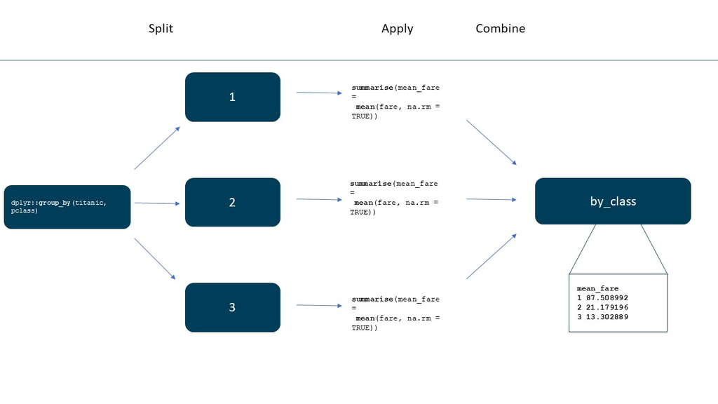

Let’s walk through what that might look like for the `titanic` `tibble`:

- Firstly, we decide to **split** the data by the `'pclass'`. This divides the `titanic` `tibble` into effectively three separate `tibbles`, one for first, one for second and one for third class.
- Secondly, we **summarise** the `tibble` using a chosen aggregation function. You can either produce an aggregate statistic for all columns, or you can select specific columns on which to do the aggregation.
- Finally, we get a **combined** `tibble` that contains the new aggregate statistics.

Let’s look at that in code:

```r
# Grouped tibble by pclass

by_class <- titanic %>%
            dplyr::group_by(pclass)
```

| pclass | survived | name_of_passenger | sex_of_passenger | age_of_passenger | sibsp | parch | ticket | fare | cabin | embarked |
| --- | --- | --- | --- | --- | --- | --- | --- | --- | --- | --- |
| 1 | 1 | Allen, Miss. Elisabeth Walton | female | 29.0000 | 0 | 0 | 24160 | 211.3375 | B5 | S |
| 1 | 1 | Allison, Master. Hudson Trevor | male | 0.9167 | 1 | 2 | 113781 | 151.5500 | C22 C26 | S |
| 1 | 0 | Allison, Miss. Helen Loraine | female | 2.0000 | 1 | 2 | 113781 | 151.5500 | C22 C26 | S |
| 1 | 0 | Allison, Mr. Hudson Joshua Creighton | male | 30.0000 | 1 | 2 | 113781 | 151.5500 | C22 C26 | S |
| 1 | 0 | Allison, Mrs. Hudson J C (Bessie Waldo Daniels) | female | 25.0000 | 1 | 2 | 113781 | 151.5500 | C22 C26 | S |
| 1 | 1 | Anderson, Mr. Harry | male | 48.0000 | 0 | 0 | 19952 | 26.5500 | E12 | S |
| 1 | 1 | Andrews, Miss. Kornelia Theodosia | female | 63.0000 | 1 | 0 | 13502 | 77.9583 | D7 | S |
| 1 | 0 | Andrews, Mr. Thomas Jr | male | NA | 0 | 0 | 112050 | 0.0000 | A36 | S |
| 1 | 1 | Appleton, Mrs. Edward Dale (Charlotte Lamson) | female | NA | 2 | 0 | 11769 | 51.4792 | C101 | S |
| 1 | 0 | Artagaveytia, Mr. Ramon | male | NA | 0 | 0 | PC 17609 | 49.5042 | NA | C |
| 1 | 0 | Astor, Col. John Jacob | male | NA | 1 | 0 | PC 17757 | 227.5250 | C62 C64 | C |
| 1 | 1 | Astor, Mrs. John Jacob (Madeleine Talmadge Force) | female | 18.0000 | 1 | 0 | PC 17757 | 227.5250 | C62 C64 | C |
| 1 | 1 | Aubart, Mme. Leontine Pauline | female | 24.0000 | 0 | 0 | PC 17477 | 69.3000 | B35 | C |
| 1 | 1 | Barber, Miss. Ellen “Nellie” | female | 26.0000 | 0 | 0 | 19877 | 78.8500 | NA | S |
| 1 | 1 | Barkworth, Mr. Algernon Henry Wilson | male | 80.0000 | 0 | 0 | 27042 | 30.0000 | A23 | S |
| 1 | 0 | Baumann, Mr. John D | male | NA | 0 | 0 | PC 17318 | 25.9250 | NA | S |
| 1 | 0 | Baxter, Mr. Quigg Edmond | male | 24.0000 | 0 | 1 | PC 17558 | 247.5208 | B58 B60 | C |
| 1 | 1 | Baxter, Mrs. James (Helene DeLaudeniere Chaput) | female | 50.0000 | 0 | 1 | PC 17558 | 247.5208 | B58 B60 | C |
| 1 | 1 | Bazzani, Miss. Albina | female | 32.0000 | 0 | 0 | 11813 | 76.2917 | D15 | C |
| 1 | 0 | Beattie, Mr. Thomson | male | 36.0000 | 0 | 0 | 13050 | 75.2417 | C6 | C |
| 1 | 1 | Beckwith, Mr. Richard Leonard | male | 37.0000 | 1 | 1 | 11751 | 52.5542 | D35 | S |
| 1 | 1 | Beckwith, Mrs. Richard Leonard (Sallie Monypeny) | female | 47.0000 | 1 | 1 | 11751 | 52.5542 | D35 | S |
| 1 | 1 | Behr, Mr. Karl Howell | male | 26.0000 | 0 | 0 | 111369 | 30.0000 | C148 | C |
| 1 | 1 | Bidois, Miss. Rosalie | female | 42.0000 | 0 | 0 | PC 17757 | 227.5250 | NA | C |
| 1 | 1 | Bird, Miss. Ellen | female | 29.0000 | 0 | 0 | PC 17483 | 221.7792 | C97 | S |
| 1 | 0 | Birnbaum, Mr. Jakob | male | 25.0000 | 0 | 0 | 13905 | 26.0000 | NA | C |
| 1 | 1 | Bishop, Mr. Dickinson H | male | 25.0000 | 1 | 0 | 11967 | 91.0792 | B49 | C |
| 1 | 1 | Bishop, Mrs. Dickinson H (Helen Walton) | female | 19.0000 | 1 | 0 | 11967 | 91.0792 | B49 | C |
| 1 | 1 | Bissette, Miss. Amelia | female | 35.0000 | 0 | 0 | PC 17760 | 135.6333 | C99 | S |
| 1 | 1 | Bjornstrom-Steffansson, Mr. Mauritz Hakan | male | 28.0000 | 0 | 0 | 110564 | 26.5500 | C52 | S |

[output cut: 1279 more lines]

Now let’s find out the mean fare paid by each class

```r
# calculating the mean from the fare column in the grouped
# dataset


by_class <- titanic %>%
            dplyr::group_by(pclass) %>%
            dplyr::summarise(mean_fare = mean(fare, na.rm = TRUE))

# To display the data

by_class
```

```
## # A tibble: 3 x 2
##   pclass mean_fare
##    <dbl>     <dbl>
## 1      1      87.5
## 2      2      21.2
## 3      3      13.3
```

**`group_by()`** is a powerful tool, particularly when you are working with any kind of hierarchical data where you might want to know something aggregate about the groups within the data, for instance:

- individuals nested in households.
- employees nested in firms.
- small area geographies (e.g. wards, output areas, postcodes etc.) nested in larger geographies (e.g. districts, counties etc.)
- countries nested in supra-national entities or, demographic, cultural and socio-economic classes.
- individuals by age, sex, ethnicity, religion etc.
- employees by grade or occupational social class.

> **We can also aggregate according to more complicated groupings**

Here we are grouping by 2 columns `"pclass"` and `"embarked"`.

```r
# Group by pclass and embarked. Then find the average fare
# paid by each group.

by_class_embarked <- titanic %>%
                     dplyr::group_by(pclass, embarked) %>%
                     dplyr::summarise(mean = mean(fare, na.rm = TRUE))
# To display the data

by_class_embarked
```

```
## # A tibble: 10 x 3
## # Groups:   pclass [3]
##    pclass embarked  mean
##     <dbl> <chr>    <dbl>
##  1      1 C        107.
##  2      1 Q         90
##  3      1 S         72.1
##  4      1 <NA>      80
##  5      2 C         23.3
##  6      2 Q         11.7
##  7      2 S         21.2
##  8      3 C         11.0
##  9      3 Q         10.4
## 10      3 S         14.4
```

Suppose with the above, the `NA` values bother us. To remove them we can add some code to our pipeline to handle this. We can use the **`drop_na()`** function from the tidyr package.

Here I have added some extra summary statistics as well, i.e standard deviation and a count.

```r
# Calculating the median fare
# dropping missing values using drop_na from tidyr package
# grouping by pclass and emabrked
# summarising by showing the median and standard deviation
# and a frequency count

median_sd_fare <- titanic %>%
               tidyr::drop_na(embarked) %>%
               dplyr::group_by(pclass, embarked) %>%
               dplyr::summarise(median_fare= median(fare, na.rm = TRUE),
                                sd_fare = sd(fare, na.rm = TRUE),
                                number_of_passengers = n())
# To display the data

median_sd_fare
```

```
## # A tibble: 9 x 5
## # Groups:   pclass [3]
##   pclass embarked median_fare sd_fare number_of_passengers
##    <dbl> <chr>          <dbl>   <dbl>                <int>
## 1      1 C              76.7    96.8                   141
## 2      1 Q              90       0                       3
## 3      1 S              52      62.0                   177
## 4      2 C              15.3    11.1                    28
## 5      2 Q              12.4     1.09                    7
## 6      2 S              15.4    14.0                   242
## 7      3 C               7.90    4.86                  101
## 8      3 Q               7.75    6.04                  113
## 9      3 S               8.05   13.1                   495
```

I plan on presenting this data, so I want something more meaningful in place than “C”, “Q” and “S”.

```r
# Calculating the median fare
# dropping missing values using drop_na from tidyr package
# using mutate to recode the variables "C","Q" and "S"
# grouping by pclass and emabrked
# summarising by shwoing the median fare and
# standard deviation and a frequency count

median_sd_fare <- titanic %>%
               tidyr::drop_na(embarked) %>%
               dplyr::mutate(embarked = recode(embarked,
                                               "C" = "Cherbourg",
                                               "Q" = "Queenstown",
                                               "S" = "Southampton")) %>%
               dplyr::group_by(pclass, embarked) %>%
               dplyr::summarise(median_fare= median(fare, na.rm = TRUE),
                                sd_fare = sd(fare, na.rm = TRUE),
                                number_of_passengers = n())
#To display the data

median_sd_fare
```

```
## # A tibble: 9 x 5
## # Groups:   pclass [3]
##   pclass embarked    median_fare sd_fare number_of_passengers
##    <dbl> <chr>             <dbl>   <dbl>                <int>
## 1      1 Cherbourg         76.7    96.8                   141
## 2      1 Queenstown        90       0                       3
## 3      1 Southampton       52      62.0                   177
## 4      2 Cherbourg         15.3    11.1                    28
## 5      2 Queenstown        12.4     1.09                    7
## 6      2 Southampton       15.4    14.0                   242
## 7      3 Cherbourg          7.90    4.86                  101
## 8      3 Queenstown         7.75    6.04                  113
## 9      3 Southampton        8.05   13.1                   495
```

We can simply visualise our data in a chart. (We are not covering how to plot here.)

[figure not shown]

## 3.1 Exercise

### **Exercise**

1. What is the average fare paid by men and women?
2. What is the median fare paid by men and women in each different class?

### **Hint**

1. What is the average fare paid by men and women?

```r
# Calculating the average fare
# Grouping by sex_of_passenger
# summary showing the mean fare

average_fare <- titanic %>%
                dplyr::group_by() %>%
                dplyr::summarise()
```

2. What is the median fare paid by men and women in each different class?

```r
# Calculating the median fare
# Grouping by sex_of_passenger and pclass
# summary showing the mean fare

median_fare <- titanic %>%
               dplyr::group_by() %>%
               dplyr::summarise()
```

### **Show Answer**

1. What is the average fare paid by men and women?

```r
# Calculating the average fare
# Grouping by sex_of_passenger
# summary showing the mean fare

average_fare <- titanic %>%
                dplyr::group_by(sex_of_passenger) %>%
                dplyr::summarise(mean_fare = mean(fare, na.rm = TRUE))

#To display the data

average_fare
```

```
## # A tibble: 2 x 2
##   sex_of_passenger mean_fare
##   <chr>                <dbl>
## 1 female                46.2
## 2 male                  26.2
```

2. What is the median fare paid by men and women in each different class?

```r
# Calculating the median fare
# Grouping by sex_of_passenger and pclass
# summary showing the mean fare
median_fare <- titanic %>%
               dplyr::group_by(sex_of_passenger, pclass) %>%
               dplyr::summarise(median_fare = median(fare, na.rm = TRUE))
#To display the data
median_fare
```

```
## # A tibble: 6 x 3
## # Groups:   sex_of_passenger [2]
##   sex_of_passenger pclass median_fare
##   <chr>             <dbl>       <dbl>
## 1 female                1       80.9
## 2 female                2       23
## 3 female                3       10.5
## 4 male                  1       49.5
## 5 male                  2       13
## 6 male                  3        7.90
```

# Summary - Summary Statistics and Aggregation

## Reminder of Learning Objectives

**You should now be able to**

- Understand how to obtain summary statistics.
- Be able to use R functions to obtain descriptive statistics.
- Be able to aggregate data in a data frame.

# 4 End of Course

You have now completed Introduction to R.

Please complete the anonymous [Post-Course Survey on the Learning Hub](https://learninghub.ons.gov.uk/mod/feedback/complete.php?id=1371&courseid).

Have a look at our other courses on our [Learning Hub dashboard](https://learninghub.ons.gov.uk/totara/dashboard/index.php?id=6) to find out how to further your learning.